# Species metadata description

# Biodiversity mapping

The following pdf gives a description of the data used in the pipeline run that corresponds to the folder this document resides in. It should be used as a guide for anyone who wants to know more about the data used in the corresponding outputs (maps and datasets) and/or would like to replicate the data.

We begin with basic information about the pipeline run.

| Characteristic | Value |
| --- | --- |
| Date | 2024-02-06 |
| Taxa | spiders, beetles |
| Region type | county |
| Region code | 50 |
| Total species | 2291 |
| Total datasets used | 13 |
| DOI | 10.15468/dl.qaj5bp |

In addition to the above, data was downloaded with a maximum uncertainty regarding coordinates of 100 metres.

| taxa | species | redListedSpecies |
| --- | --- | --- |
| beetles | 1787 | 11 |
| spiders | 504 | 3 |

| dsName | dataType | observations | redListedObservations |
| --- | --- | --- | --- |
| Freshwater benthic invertebrates ecological collection NTNU University Museum | PA | 1851585 | 0 |
| Terrestrial and limnic invertebrates systematic collection, NTNU University Museum | PO | 19783 | 117 |
| NINA insect database | PO | 12751 | 6538 |
| Norwegian Species Observation Service | PO | 9567 | 119 |
| National insect monitoring in Norway | Counts | 2260 | 0 |
| iNaturalist Research-grade Observations | PO | 197 | 0 |
| Entomological collections, UiB | PO | 152 | 0 |
| Entomology, Oslo (O) UiO | PO | 63 | 0 |
| Artportalen (Swedish Species Observation System) | PO | 14 | 0 |
| Entomology collection, UiT Tromsø Museum | PO | 10 | 0 |

The following gives species richness for observations across the surveyed region by taxa.

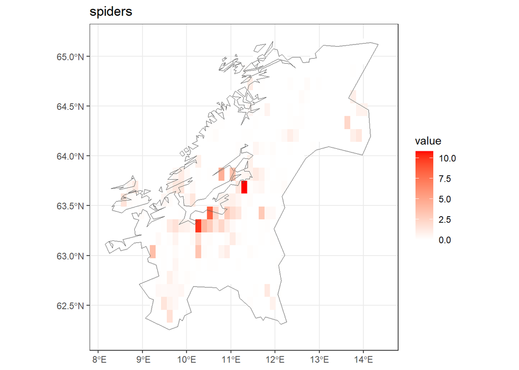

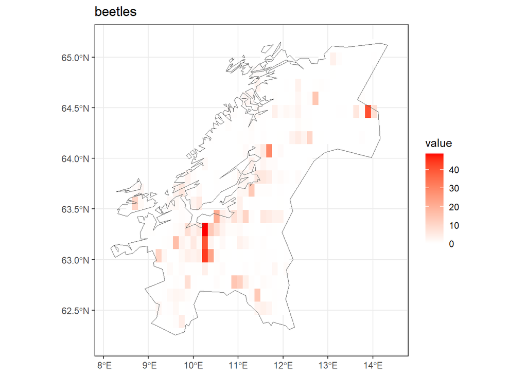

The following gives spatial density for observations across the surveyed region by taxa.

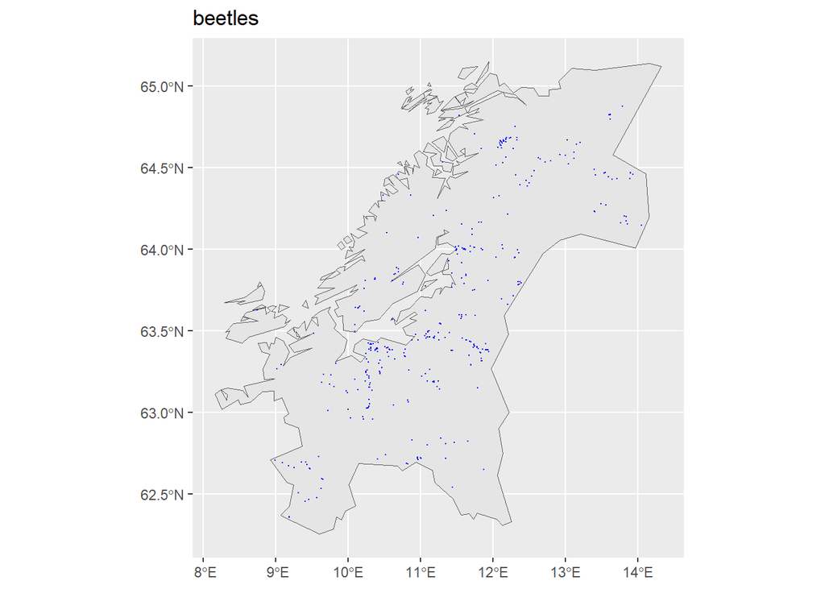

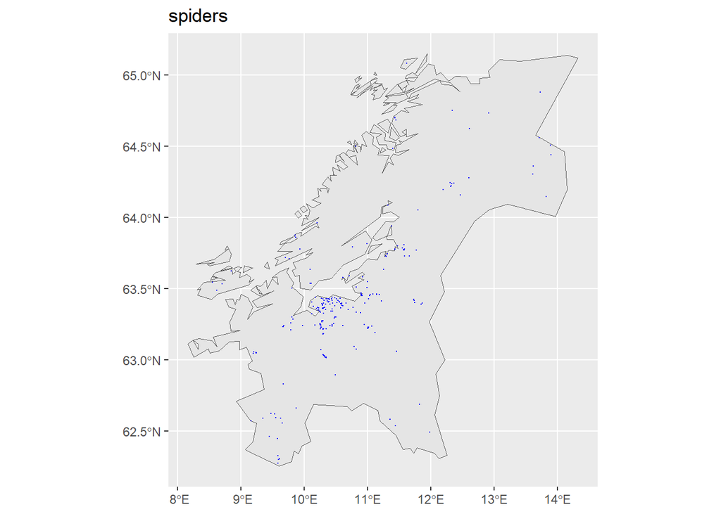

## Appendices

### Appendix 1

The tables below give further information on the observations used for our pipeline run.

Total numbers of observations used in pipeline run for each dataset by taxa.

| taxa | dsName | Observations |
| --- | --- | --- |
| beetles | Freshwater benthic invertebrates ecological collection NTNU University Museum | 1851585 |
| beetles | Terrestrial and limnic invertebrates systematic collection, NTNU University Museum | 14094 |
| beetles | NINA insect database | 9331 |
| beetles | Norwegian Species Observation Service | 7424 |
| beetles | National insect monitoring in Norway | 1261 |
| beetles | iNaturalist Research-grade Observations | 153 |
| beetles | Entomology, Oslo (O) UiO | 63 |
| beetles | Artportalen (Swedish Species Observation System) | 13 |
| beetles | Entomology collection, UiT Tromsø Museum | 10 |
| beetles | naturgucker | 6 |
| beetles | Norwegian Biodiversity Information Centre - Other datasets | 5 |
| beetles | Observation.org, Nature data from around the World | 5 |
| beetles | Entomological collections, UiB | 3 |
| spiders | Terrestrial and limnic invertebrates systematic collection, NTNU University Museum | 5689 |
| spiders | NINA insect database | 3420 |
| spiders | Norwegian Species Observation Service | 2143 |
| spiders | National insect monitoring in Norway | 999 |
| spiders | Entomological collections, UiB | 149 |
| spiders | iNaturalist Research-grade Observations | 44 |
| spiders | Artportalen (Swedish Species Observation System) | 1 |

Total numbers of observations used in pipeline run for each data type by taxa.

| taxa | dataType | Observations |
| --- | --- | --- |
| beetles | PA | 1851585 |
| beetles | PO | 31107 |
| beetles | Counts | 1261 |
| spiders | PO | 11446 |
| spiders | Counts | 999 |